# Babylab analysis - Main Results

M. Rolland

Last modified: 2021-06-10

Remarks:

# 1 Introduction

# 2 Population description

| name | N | stat |
| --- | --- | --- |
| **Age group** |  |  |
| 5 months | 46 | 17 % |
| 12 months | 67 | 25 % |
| 24 months | 150 | 57 % |
| **Experiment hour** |  |  |
| 8AM | 1 | 0 % |
| 9AM | 82 | 31 % |
| 10AM | 85 | 32 % |
| 11AM | 43 | 16 % |
| 12PM | 2 | 1 % |
| 1PM | 8 | 3 % |
| 2PM | 12 | 5 % |
| 3PM | 18 | 7 % |
| 4PM | 12 | 5 % |
| **Child sex** |  |  |
| Male | 144 | 55 % |
| Female | 119 | 45 % |
| **Parity** |  |  |
| First child | 131 | 50 % |
| Second child | 109 | 41 % |
| Third child or more | 23 | 9 % |
| **Maternal depression during pregnancy** |  |  |
| HAD <= 11 | 186 | 71 % |
| HAD > 11 | 73 | 28 % |
| Missing | 4 | 2 % |
| **Maternal tobacco consumption during pregnancy** |  |  |
| No | 224 | 85 % |
| Yes | 32 | 12 % |
| Missing | 7 | 3 % |
| **Continuous variables (mean(SD))** |  |  |
| Maternal age | 263 | 32.32 (3.92) |
| Breastfeeding duration (days) | 260 | 29.43 (16.24) |

# 3 Exposure description

Description of pregnancy exposure levels per sampling period

|  | N | Second Trimester mean | Second Trimester median | Second Trimester p5 | Second Trimester p95 | Third Trimester mean | Third Trimester median | Third Trimester p5 | Third Trimester p95 |
| --- | --- | --- | --- | --- | --- | --- | --- | --- | --- |
| DEHP_ms | 263 | 0.13 | 0.10 | 0.05 | 0.28 | 0.13 | 0.11 | 0.05 | 0.27 |
| DINCH_ms | 263 | 0.03 | 0.01 | 0.00 | 0.12 | 0.03 | 0.01 | 0.00 | 0.10 |
| DiNP_ms | 263 | 0.08 | 0.04 | 0.02 | 0.23 | 0.07 | 0.04 | 0.02 | 0.18 |
| MBzP | 263 | 6.94 | 4.44 | 1.47 | 18.53 | 7.69 | 3.97 | 1.36 | 23.96 |
| MEP | 263 | 52.97 | 24.14 | 6.45 | 179.06 | 38.65 | 21.29 | 4.62 | 104.28 |
| MiBP | 263 | 19.91 | 14.74 | 6.89 | 49.68 | 17.52 | 14.18 | 5.43 | 43.23 |
| MnBP | 263 | 13.89 | 10.80 | 4.65 | 36.73 | 13.78 | 10.98 | 3.96 | 32.94 |
| ohMPHP | 263 | 1.10 | 0.82 | 0.50 | 2.33 | 1.28 | 0.77 | 0.48 | 2.46 |

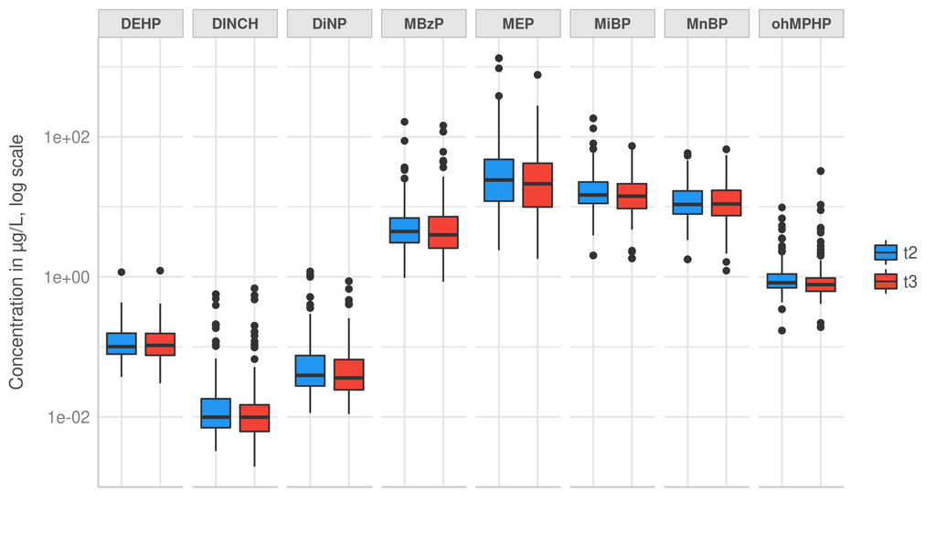

Comparable exposure levels between both sampling periods.

# 4 Outcome description

Description of babylab score distributions per age category

| score | 5 months N | 5 months mean | 5 months median | 5 months p5 | 5 months p95 | 12 months N | 12 months mean | 12 months median | 12 months p5 | 12 months p95 | 24 months N | 24 months mean | 24 months median | 24 months p5 | 24 months p95 |
| --- | --- | --- | --- | --- | --- | --- | --- | --- | --- | --- | --- | --- | --- | --- | --- |
| fix_dur | 46 | 416.56 | 407.00 | 328.35 | 545.55 | 67 | 391.84 | 383.00 | 322.62 | 484.62 | 150 | 358.47 | 352.00 | 285.50 | 450.80 |
| look_t | 46 | 4100.34 | 4185.42 | 3536.86 | 4483.91 | 67 | 3917.54 | 3988.96 | 3266.83 | 4368.14 | 150 | 4141.98 | 4176.50 | 3815.63 | 4386.30 |
| mean_map | 46 | 0.04 | 0.04 | 0.03 | 0.06 | 67 | 0.06 | 0.06 | 0.04 | 0.07 | 150 | 0.06 | 0.06 | 0.04 | 0.07 |
| novelty | 46 | 0.04 | 0.05 | -0.27 | 0.34 | 67 | 0.08 | 0.07 | -0.21 | 0.45 | 150 | 0.10 | 0.10 | -0.17 | 0.35 |
| pct_eyes | 46 | 0.73 | 0.74 | 0.44 | 0.95 | 67 | 0.73 | 0.78 | 0.39 | 0.93 | 150 | 0.68 | 0.73 | 0.30 | 0.91 |
| reac_t | 46 | 464.04 | 442.00 | 340.00 | 628.80 | 67 | 322.97 | 323.50 | 225.45 | 418.97 | 150 | 297.28 | 292.00 | 211.30 | 395.55 |

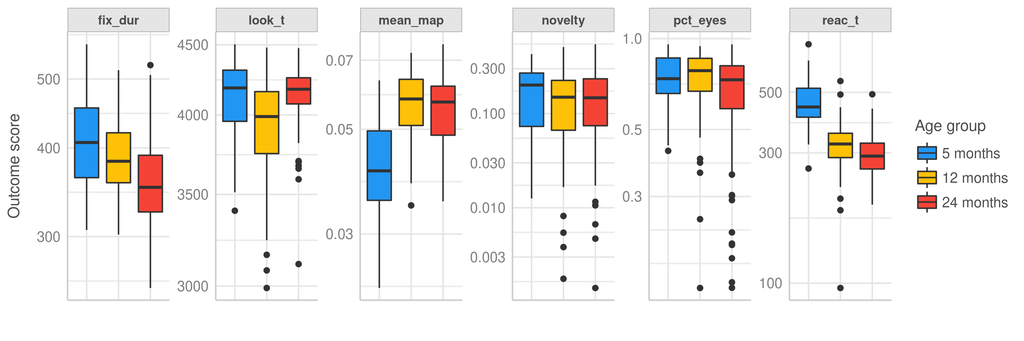

- **Decrease of fixations duration** with increasing age
- **Lower attention times** at 12 months
- **Lower mean maps** at 5 months (means there is more variability in the gaze location from one child to another)
- Comparable times of **reaction to novelty**
- Comparable levels of **eye looking** (maybe lower at 24m, needs formally testing)
- **Reaction times decrease** with increasing age